# Selection Criteria for Parameters in grasps

## Introduction

Precision matrix estimation requires selecting appropriate regularization parameter *λ* to balance sparsity (number of edges) and model fit (likelihood), and a mixing parameter *α* to trade off between element-wise (individual-level) and block-wise (group-level) penalties.

## Background: Negative Log-Likelihood

In a Gaussian graphical model (GGM), the data matrix *X*<sub>*n* × *p*</sub> consists of *n* independent and identically distributed observations *X*<sub>1</sub>, …, *X*<sub>*n*</sub> drawn from *N*<sub>*p*</sub>(*μ*, *Σ*). Let *Ω* = *Σ*<sup>−1</sup> denote the precision matrix, and define the empirical covariance matrix as $S = n^{-1} \sum_{i=1}^n (X_i-\bar{X})(X_i-\bar{X})^\top$. Up to an additive constant, the negative log-likelihood (nll) for *Ω* simplified to
$$\mathrm{nll}(\Omega) = \frac{n}{2}[-\log\det(\Omega) + \mathrm{tr}(S\Omega)].$$
The edge set *E*(*Ω*) is determined by the non-zero off-diagonal entries: an edge (*i*, *j*) is included if and only if *ω*<sub>*i**j*</sub> ≠ 0 for *i* < *j*. The number of edges is therefore given by |*E*(*Ω*)|.

## Selection Criteria

1. AIC: Akaike information criterion (Akaike 1973)

*Ω̂*<sub>AIC</sub> = arg min <sub>*Ω*</sub>{2 nll(*Ω*) + 2 |*E*(*Ω*)|}.

2. BIC: Bayesian information criterion (Schwarz 1978)

*Ω̂*<sub>BIC</sub> = arg min <sub>*Ω*</sub>{2 nll(*Ω*) + log (*n*) |*E*(*Ω*)|}.

3. EBIC: Extended Bayesian information criterion (Chen and Chen 2008; Foygel and Drton 2010)

*Ω̂*<sub>EBIC</sub> = arg min <sub>*Ω*</sub>{2 nll(*Ω*) + log (*n*) |*E*(*Ω*)| + 4 *ξ* log (*p*) |*E*(*Ω*)|},

where *ξ* ∈ [0, 1] is a tuning parameter. Setting *ξ* = 0 reduces EBIC to the classic BIC.

4. HBIC: High dimensional Bayesian information criterion (Wang et al. 2013; Fan et al. 2017)

*Ω̂*<sub>HBIC</sub> = arg min <sub>*Ω*</sub>{2 nll(*Ω*) + log [log (*n*)] log (*p*) |*E*(*Ω*)|}.

5. *K*-fold cross validation with negative log-likelihood loss.

Figure 1 illustrates the *K*-fold cross-validation procedure used for tuning the parameters *λ* and *α*. The notation #*λ* and #*α* denotes the number of candidate values considered for *λ* and *α*, respectively, forming a grid of #*λ* × #*α* total parameter combinations. For each of the *K* iterations, negative log-likelihood loss is evaluated for all parameter combinations, yielding *K* performance values per combination. The optimal parameter pair is selected as the one achieving the lowest average loss across the *K* iterations.

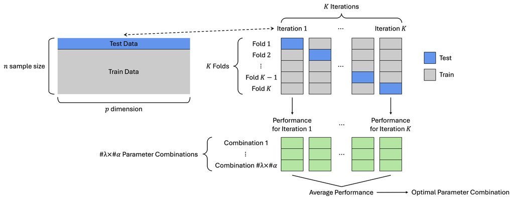

Figure 1: *K*-fold cross-validation procedure for tuning (*λ*, *α*).

## Reference

Akaike, Hirotogu. 1973. “Information Theory and an Extension of the Maximum Likelihood Principle.” In *Second International Symposium on Information Theory*, edited by Boris Nikolaevich Petrov and Frigyes Csáki. Akadémiai Kiadó.

Chen, Jiahua, and Zehua Chen. 2008. “Extended Bayesian Information Criteria for Model Selection with Large Model Spaces.” *Biometrika* 95 (3): 759–71. https://doi.org/10.1093/biomet/asn034.

Fan, Jianqing, Han Liu, Yang Ning, and Hui Zou. 2017. “High Dimensional Semiparametric Latent Graphical Model for Mixed Data.” *Journal of the Royal Statistical Society Series B: Statistical Methodology* 79 (2): 405–21. https://doi.org/10.1111/rssb.12168.

Foygel, Rina, and Mathias Drton. 2010. “Extended Bayesian Information Criteria for Gaussian Graphical Models.” In *Advances in Neural Information Processing Systems 23 (NIPS 2010)*, edited by J. Lafferty, C. Williams, J. Shawe-Taylor, R. Zemel, and A. Culotta. Curran Associates, Inc. https://dl.acm.org/doi/10.5555/2997189.2997257.

Schwarz, Gideon. 1978. “Estimating the Dimension of a Model.” *The Annals of Statistics* 6 (2): 461–64. https://doi.org/10.1214/aos/1176344136.

Wang, Lan, Yongdai Kim, and Runze Li. 2013. “Calibrating Nonconvex Penalized Regression in Ultra-High Dimension.” *The Annals of Statistics* 41 (5): 2505–36. https://doi.org/10.1214/13-AOS1159.